# Regression and model validation

*This week I have covered data wrangling and linear regression analysis.*

```r
date()
```

```
## [1] "Fri Nov 12 00:33:34 2021"
```

```r
learning2014 <- read.csv(file = "data/learning2014.csv", header = TRUE)
str(learning2014)
```

```
## 'data.frame':    166 obs. of  8 variables:
##  $ X       : int  1 2 3 4 5 6 7 8 9 10 ...
##  $ gender  : chr  "F" "M" "F" "M" ...
##  $ age     : int  53 55 49 53 49 38 50 37 37 42 ...
##  $ attitude: num  3.7 3.1 2.5 3.5 3.7 3.8 3.5 2.9 3.8 2.1 ...
##  $ deep    : num  3.58 2.92 3.5 3.5 3.67 ...
##  $ stra    : num  3.38 2.75 3.62 3.12 3.62 ...
##  $ surf    : num  2.58 3.17 2.25 2.25 2.83 ...
##  $ points  : int  25 12 24 10 22 21 21 31 24 26 ...
```

```r
dim(learning2014)
```

```
## [1] 166   8
```

### 1. Information of dataset

1. Gender (Gender: M (Male), F (Female))
2. Age (in years) derived from the date of birth
3. Attitude (Global attitude towards statistics)
4. Deep (ASSIST scale)
5. Strategic (ASSIST scale)
6. Surface (ASSIST scale)
7. Points (Exam points)

Background of measures:

Measures A and C are based on parts A and C in ASSIST (Approaches and Study Skills Inventory for Students) http://www.etl.tla.ed.ac.uk/publications.html#measurement and D is based on SATS (Survey of Attitudes Toward Statistics) http://www.evaluationandstatistics.com/

The items of the central measure in this study (ASSIST B) are named so that the connections to the corresponding dimensions (Deep/SUrface/STrategic) can be easily seen.

### 2. Graphical overview of the data and summaries of the variables

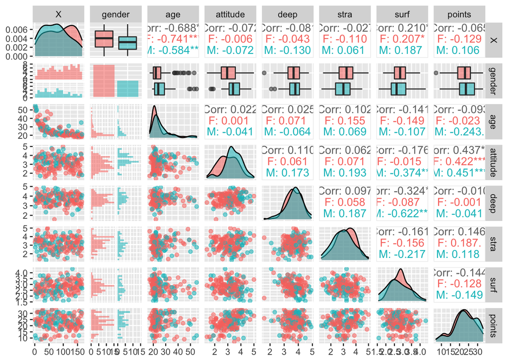

```r
# access the GGally and ggplot2 libraries
library(GGally)
library(ggplot2)

# create a more advanced plot matrix with ggpairs() : draws all possible scatter plots from the columns of a data frame, resulting in a scatter plot matrix.
p <- ggpairs(learning2014, mapping = aes(col = gender, alpha = 0.3), lower = list(combo = wrap("facethist", bins = 20)))
# draw the plot
p
```

### Interpret the results

From above graphical overview, we can see the relationships between the variables. It shows the correlations between different variables and distributions of each variables with respect to ‘gender’ variable.

The colour of plots is defined with the ‘gender’ variable. Pink color plots correspond to Female and green color for Male.

In this graphical overview, we can see the correlations between all variables. We have a negative correlation between points and age. The trend is that when age increases points decreases. And there is a positive correlation between points are attitudes. The trend is that when attitude increases point increases. If we consider correlation between surf variable and deep variable, there is a strong correlation in males where as a weak correlation in females. However, we can also observe that there are approximately twice number of more female than male.

### 3. Fit a regression model

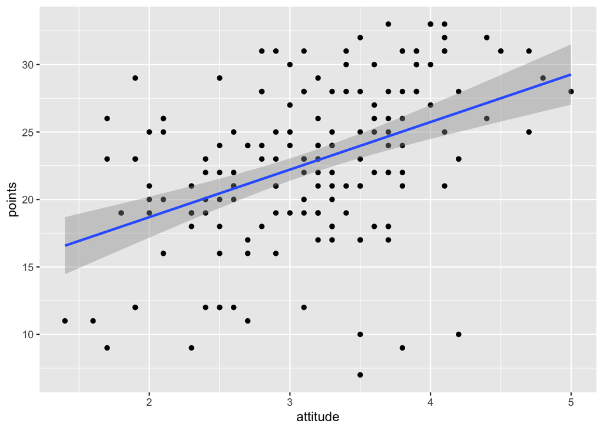

```r
# a scatter plot of points versus attitude
library(ggplot2)
qplot(attitude, points, data = learning2014) + geom_smooth(method = "lm")
```

```r
# fit a linear model # create a regression model with multiple explanatory variables
my_model <- lm(points ~ attitude + stra + deep, data = learning2014)

# print out a summary of the model
summary(my_model)
```

```
##
## Call:
## lm(formula = points ~ attitude + stra + deep, data = learning2014)
##
## Residuals:
##      Min       1Q   Median       3Q      Max
## -17.5239  -3.4276   0.5474   3.8220  11.5112
##
## Coefficients:
##             Estimate Std. Error t value Pr(>|t|)
## (Intercept)  11.3915     3.4077   3.343  0.00103 **
## attitude      3.5254     0.5683   6.203 4.44e-09 ***
## stra          0.9621     0.5367   1.793  0.07489 .
## deep         -0.7492     0.7507  -0.998  0.31974
## ---
## Signif. codes:  0 '***' 0.001 '**' 0.01 '*' 0.05 '.' 0.1 ' ' 1
##
## Residual standard error: 5.289 on 162 degrees of freedom
## Multiple R-squared:  0.2097, Adjusted R-squared:  0.195
## F-statistic: 14.33 on 3 and 162 DF,  p-value: 2.521e-08
```

### Interpret the results

Linear model: formula = points ~ attitude + stra + deep

The best model is found by minimizing the prediction errors (residuals) that model would make. Goal is to minimize the sum of squared residuals. The parameters of residuals are as follows.

Parameters of Residuals:

Min -17.5239, 1Q -3.4276, Median 0.5474, 3Q 3.8220, Max 11.5112.

Coefficients give the estimates of the model parameters corresponding to each variable along with the intercept. Intercept corresponds to the value in y-axis where linear model intersects y-axis.

Coefficients:

(Intercept) 11.3915  
attitude 3.5254  
stra 0.9621  
deep -0.7492

P-values:

The P-value which corresponds to attitude is very small. Therefore, we can conclude there is a strong correlation between the points variable and attitude variable. Due to high p-value of deep variable, there is the least correlation between points variable and deep variable. P-values are as follows.

attitude 4.44e-09 *** stra 0.07489 .  
deep 0.31974

We can even observe standard error values of parameter estimates from Std. Error column in the summary - table of coefficients.

### Remove less correlated variable

deep variable does not have a statistically significant relationship with the target variable; points.

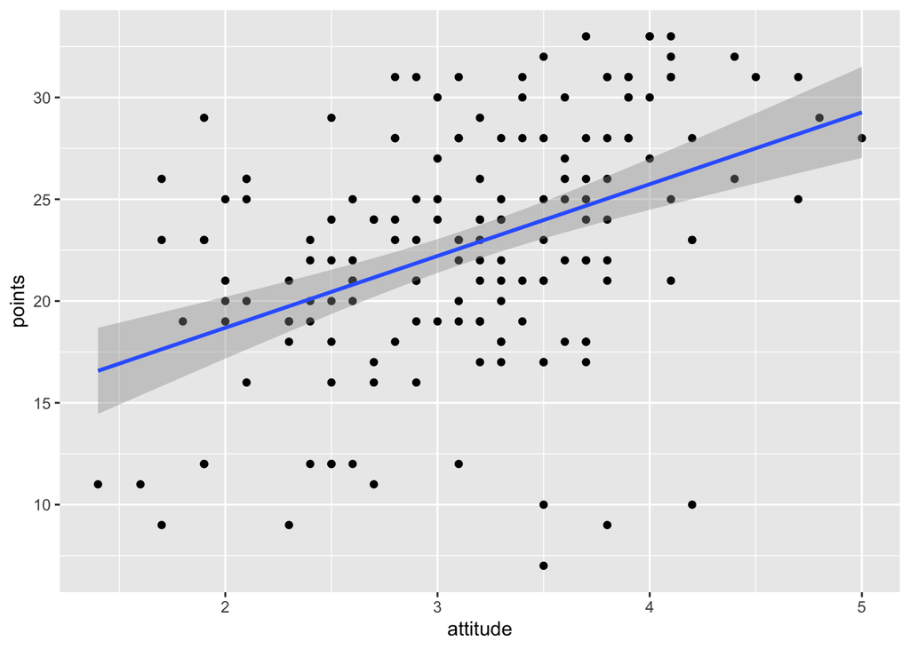

```r
# a scatter plot of points versus attitude
library(ggplot2)
qplot(attitude, points, data = learning2014) + geom_smooth(method = "lm")
```

```r
# fit a linear model # create a regression model with multiple explanatory variables
my_model <- lm(points ~ attitude + stra , data = learning2014)

# print out a summary of the model
summary(my_model)
```

```
##
## Call:
## lm(formula = points ~ attitude + stra, data = learning2014)
##
## Residuals:
##      Min       1Q   Median       3Q      Max
## -17.6436  -3.3113   0.5575   3.7928  10.9295
##
## Coefficients:
##             Estimate Std. Error t value Pr(>|t|)
## (Intercept)   8.9729     2.3959   3.745  0.00025 ***
## attitude      3.4658     0.5652   6.132 6.31e-09 ***
## stra          0.9137     0.5345   1.709  0.08927 .
## ---
## Signif. codes:  0 '***' 0.001 '**' 0.01 '*' 0.05 '.' 0.1 ' ' 1
##
## Residual standard error: 5.289 on 163 degrees of freedom
## Multiple R-squared:  0.2048, Adjusted R-squared:  0.1951
## F-statistic: 20.99 on 2 and 163 DF,  p-value: 7.734e-09
```

### 4. Relationship between explanatory variables and the target variables

Here, it was considered, points as the target variable and attitude, stra and deep as the explanatory variables. It implies we are trying to estimate points variable as a multiple linear model of attitude, stra and deep variables. We can see that there is a statistically significant relationship between exam points and attitude, but not with deep. This means that deep does not interpret anything about exam points, but the attitude do interpret. Therefore, deep variable was removed from the consideration and remodelled only with attitude and stra variables.

### Multiple R squared of the model

With attitude + stra + deep variables -> Multiple R-squared: 0.2097 -> approximately 20% With attitude + stra variables -> Multiple R-squared: 0.2048 -> approximately 20%

Multiple R-squared implies the multiple correlation coefficient between three or more variables. It implies how strong the linear relationship is. In other words, how well the regression model fits the observed data. This value ranges from 0 to 1. For example, an R-squared of 20% reveals that 20% of the data fit the regression model. Generally, a higher R-squared indicates a better fit for the model. In this case, we can see after we remove deep variable, Multiple R-squared approximately remains unchanged. That is because deep variable does not have a high impact towards point variable.

### 5. Diagnostic plots

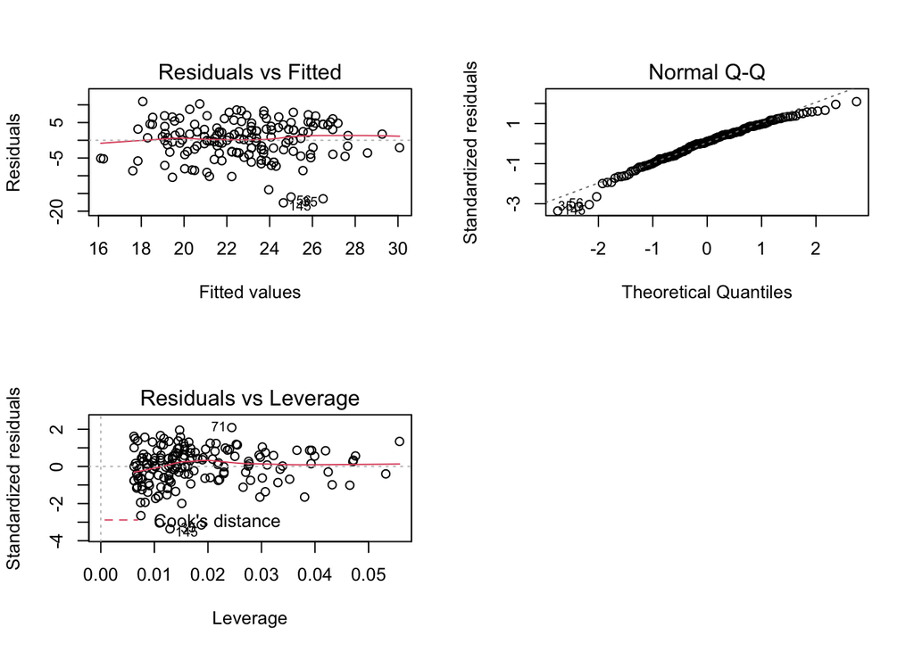

```r
# a scatter plot of points versus attitude
# create a regression model with multiple explanatory variables
my_model2 <- lm(points ~ attitude + stra, data = learning2014)

# draw diagnostic plots using the plot() function. Choose the plots 1, 2 and 5
par(mfrow = c(2,2))
plot(my_model2, which = c(1,2,5))
```

### The assumptions of the model

Model assumptions in linear regression are as follows.

1. In a linear regression model an obvious assumption is linearity: the target variable is modelled as a linear combination of the model parameters.
2. The errors are normally distributed.

Analyzing the residuals of the model provides a method to explore the validity of model assumptions.

Assumptions related to errors are as follows.

1. The errors are normally distributed.
2. The errors are not correlated.
3. The errors have a constant variance.
4. The size of a given error does not depend on the explanatory variables. (constant variance of errors)

### Interpret the validity of those assumptions based on the diagnostic plots

Residuals vs Fitted-plot provides a method to explore the assumption that the size of a given error does not depend on the explanatory variables. Any pattern will imply a problem in the assumption. As we can see in above Residuals vs Fitted-plot, there is a reasonable random spread of points. We can not observe a pattern; but a constant variance. It confirms the assumption that the size of the errors does not depend on the explanatory variables.

Normal QQ-plot provides a method to explore the assumption that errors of the model are normally distributed. As we can see in above QQ-plot, there is a reasonable fit in the middle. But in the corners, there is a clear deviation which makes the normality assumption being questionable.

The Residuals vs leverage shows how much impact single point has on the model. It helps to identify which points have an unusually high impact. As we can see in above Residuals vs leverage plot, there are no highly unusual outliers.